# Guided Exercise 2

10/8/2021

# Predicting Politics

As you have seen, coverage of political polling dominates news coverage of elections in the United States (and, indeed, in nearly every democracy). We are going to put the skills you have learned to use and give you a chance to spread your wings a bit.

In class we have worked with data from 2020 – at both the national and state-level to characterize how the national popular vote changed over time as well as what the state-level polls suggested about the outcomes in each state. But how do the results for 2020 compare to 2016?

Imagine that you have been hired by your favorite news organization to evaluate how much money and resources they should devote to polling and covering polling in 2024. To do this, they want you to conduct a post-mortum about how well the polls in the last two presidential elections in the United State (2016 & 2020) were able to predict what happened. In particular, they want your team to analyze how well the polls were able to predict the outcome of 2016 and 2020 using polling data alone, what you can say about the error and, if you really want to, to see whether you can improve the prediction for 2020 using what happened in 2016 (to see what they might do in 2024 given the 2020 results).

Write up a memo in `RMarkdown` that presents a narrative that answers the following three questions in a coherent manner. Do not just write a separate paragraph for each part. Instead, write a coherent narrative/argument about the ability to use polling to predict election outcomes in 2016 and 2020. If you choose to do the bonus/challenge item, write about what you would propose to change for how we should use polls to predict outcomes in 2024 based on how you would change the 2020 prediction using what happened in 2016.

## Part 1. National Popular Vote in 2020 and 2016

- First, reproduce the following figure plotting the *two-candidate vote share* for Biden and Trump over time.
- HINT1: This is largely just replicating what we did in class.
- HINT2: Instead of using a customized smoother, here we are keeping things “simple” using `geom_smooth`

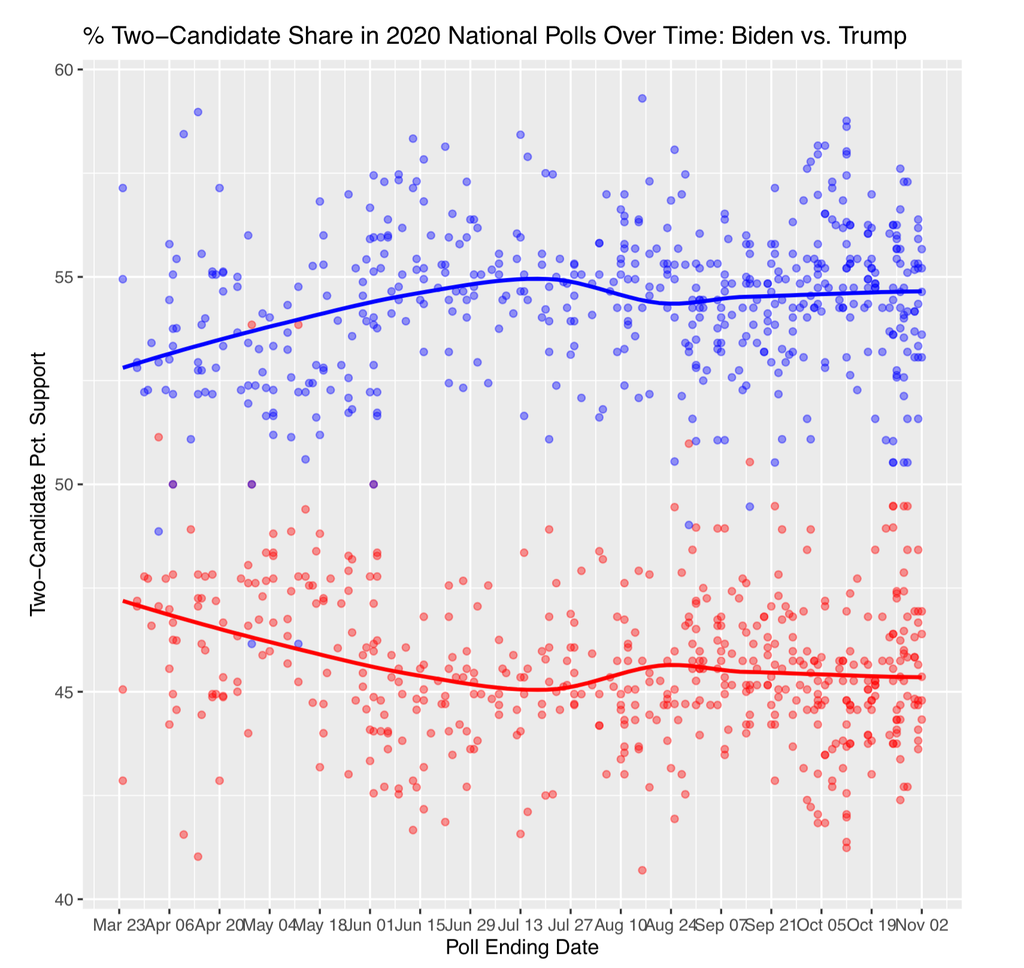

- Second, using the national polls for 2016 – `Pres2016.PV` – create a similar plot for how the polls for the national popular vote changed over time for 2016? What do you observe about the similarities and differences in 2020 and 2016?
- Third, redo this using only the last 100 days for both 2020 and 2016. Does this suggest a different characterization than if we plot the entire period for each? Why or why not?

BONUS: Can you plot the `margin` as a function of the Days until Election Day for the last 100 days for both? Which do you think is better for us to focus on and why?

## Part 2. How well did the polls predict the Electoral College outcome in 2016?

- Fourth, in class we predicted the Electoral College vote in 2020. Can you do the same in 2016 using `Pres2016.StatePolls`? Justify any decisions you make to create that estimate (i.e., why is it reasonable). How well did it do?

## Part 3. What Happened? (Open Ended)

Both datasets have what the actual vote received by Biden/Clinton (`DemCertVote`) and Trump (`RepCertVote`). It also has whether the state was won by the `Dem` or the `Rep` in `Winner`. What can you say about the nature of the polling error in 2016 and 2020? Be creative. We are not looking for anything in particular, but given all the data you now have, what are a few conclusion(s) you draw about polling error in 2016 and 2020?

## BONUS CHALLENGE:

Not required, but can you use the 2016 results to improve the estimates of 2020? How might you change your 2020 predictions given the patterns you note in 2016 and how much can you improve the prediction relative to part 2?

NOTE: If you cannot figure out how to do exactly what you want to do in R, describe what you would do if you could – preferably using “pseudo-code” (i.e., describe the manipulations using functions you are aware of to describe how you are thinking of trying to do what you want to do).